# Data Analysis on Factors Affecting Interest Rates

İlayda Tutal

05 12 2020

# Introduction

Interest rates play an important role in the overall economy. They affect economic decision makings such as where to invest, and to what extend. Interest rates could be determined according to many factors and could be affected as well. Most of us probably are familiar with interest rates and the changes in them over months or years. According to my knowledge of economics and small-scale research, I needed to ask this question: **“Are interest rates statistics related to exchange rates, domestic borrowing, the supply of money?”**. So, naturally, weighted interest rates data is necessary for the beginning. I use personal finance credit interest rate data since a home or car loan would be too specific for my research question.

- First of all, it is stated that in economics that: all else being equal, a larger **money supply** lowers market interest rates, making it less expensive for consumers to borrow. Conversely, smaller money supplies tend to raise market interest rates, making it pricier for consumers to take out a loan. This will be analyzed in the following parts with time-series data. Therefore, the Turkish Republic Central Bank (money level in terms of Turkish Liras) data is going to be used.
- Secondly, in economies where savings are insufficient, the public resorting to **domestic borrowing** to finance public deficits has an impact on interest rates (Özbilen, 2015:507). Therefore, interest rates are increased to find new debt. Additionally, according to my research on domestic borrowings, Demir and Sever (2008) made research about how domestic borrowing affects multiple economic measures, one of them being interest rates. Their research includes the years 1987-2007 and supported the argument presented by Özbilen. We will see if our data is going to support as well, or otherwise. So, Government Debt Securities data is going to be used.
- Last but not least, the effect of **exchange rates** is going to be analyzed. We all have a basic understanding of how exchange rates affect our daily life or economic decisions and in the following parts, we will see how it is related to interest rates. Therefore, the rate of exchange (EUR) is going to be used.

# Data Manipulation & Visualization

Necessary data is taken from the Electronic Data Delivery System, [EVDS](https://evds2.tcmb.gov.tr/). To make a reasonable analysis, an 8-years period was chosen. In EVDS, statistics are accessed in their original frequency, as time series.

After gathering all the necessary data in a data table, and made the necessary manipulations, we can take a look at the first 10 rows:

```
##           date weighted_int_rate money_supply domestic_borrowing     euro year
##  1: 2013-01-15           14.0550        16433            8165048 2.341359 2013
##  2: 2013-02-15           13.7550        22840            8470370 2.368875 2013
##  3: 2013-03-15           13.5240         8053            9012841 2.344810 2013
##  4: 2013-04-15           13.4500        16271            9315913 2.335514 2013
##  5: 2013-05-15           12.6720         8429            7950187 2.366627 2013
##  6: 2013-06-15           11.8200         8235            7726557 2.498660 2013
##  7: 2013-07-15           12.4650        24063            7229478 2.523952 2013
##  8: 2013-08-15           13.1180        18153            7671986 2.601842 2013
##  9: 2013-09-15           13.9400        10373            8478717 2.690190 2013
## 10: 2013-10-15           13.8125         7259            9020528 2.713178 2013
```

Now, we can see the change in interest rate data with a line plot easily.

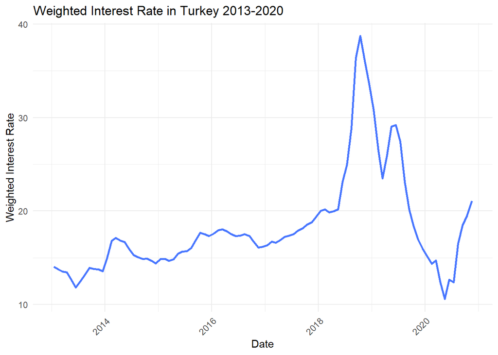

As is seen above, weighted interest rates change over the years. It has no seasonality which is not so surprising since season/month does not usually affect the interest rate. In addition to that, there is a noticeable peak after 2018. Reasons for this might depend on various things.

Also, to get a general idea about how our data is distributed, it could be nice to see histograms:

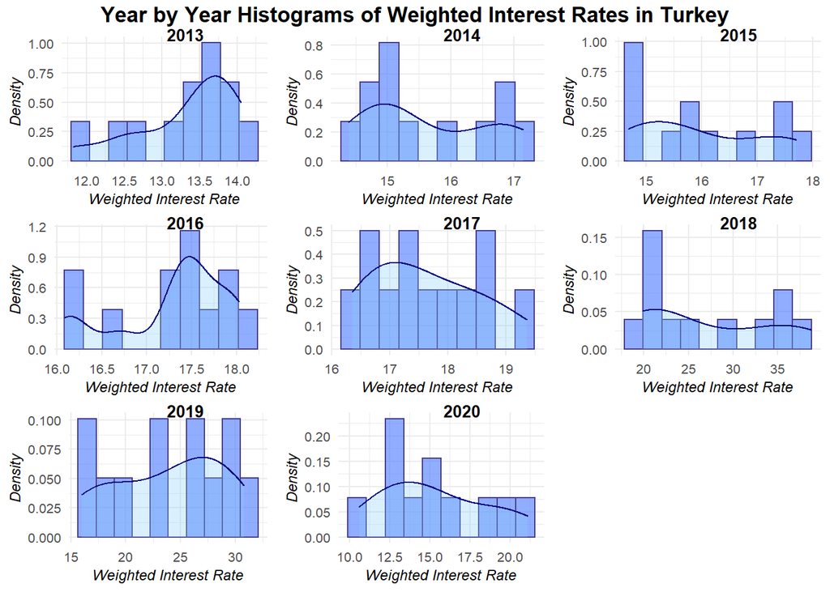

We can see that the interest rate doesn’t change over time with a pattern in other words there is no seasonality. There is a noticeable increase in 2018 which can be seen in the x-axis on the histogram of 2018 as well. As it can be seen from histograms after 2016, we can not easily say that the histograms are left-skewed or right-skewed since they have more straight shapes. We can interpret this as the distribution of the rates over the year was balanced.

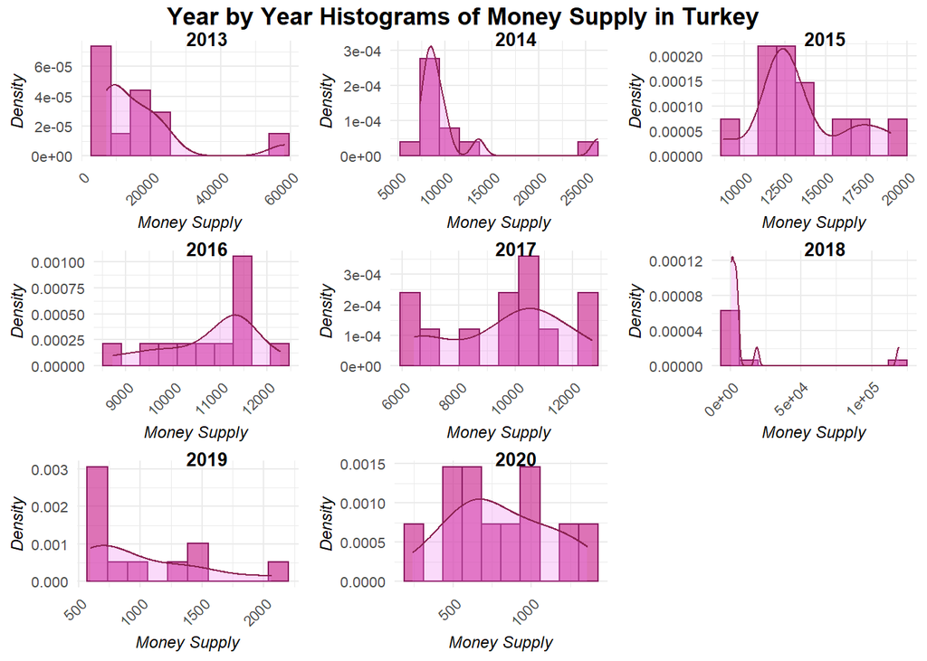

Unlike interest rate histograms, money supply histograms differ more depending on the year. Again in 2018, we have some critical change which may be an explanation for the peak in the line plot in interest rate. However, we cannot say just looking at the histograms, this is why we need further analysis. In the first three years, the shape of the distributions is similar to each other. But after that, we see more left-skewed shapes in the histograms.

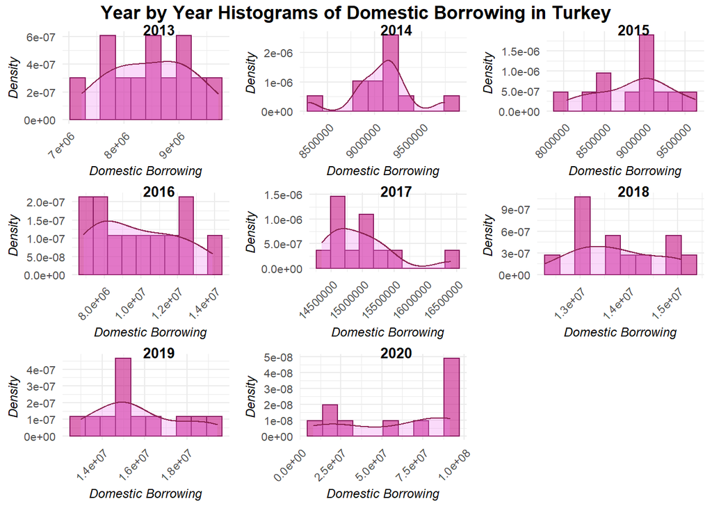

Domestic borrowing data is most likely to can be fitted in a normal distribution so far. We can say that there is not a big difference between the shapes of histograms in successive 2-3 years. Since these are huge numbers, the similarity between successive years is quite reasonable. This study includes only 8 years; therefore, there is not a specific peak or unexpected distribution. In other words, the domestic borrowing of Turkey probably differs more when we look before a war, and some time after a war.

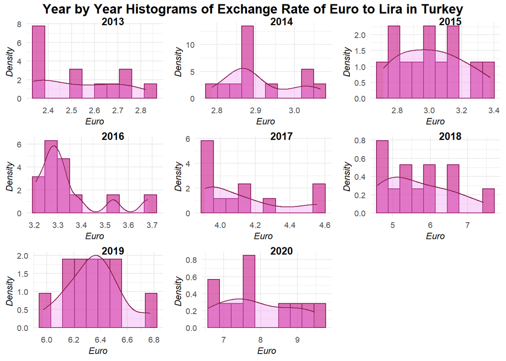

Last but not least, we have the histograms for the exchange rate of the euro to lira. This is something we all constantly observe, hear, or somewhat have a sense about. Not only the shapes but also the overall increase can be seen from the x-axis again. Until 2016, it can be stated that there is not a huge difference in exchange rates although the shapes are not very similar. However, after 2016, the increase in the exchange rate accelerated. 2016, the year that the coup attempt in Turkey and then to fluctuations in the economy this year, many of us have witnessed it closely.

## Correlation Analyses

To investigate the dependence between multiple variables at the same time, scatter plots with the correlation coefficients can be seen below:

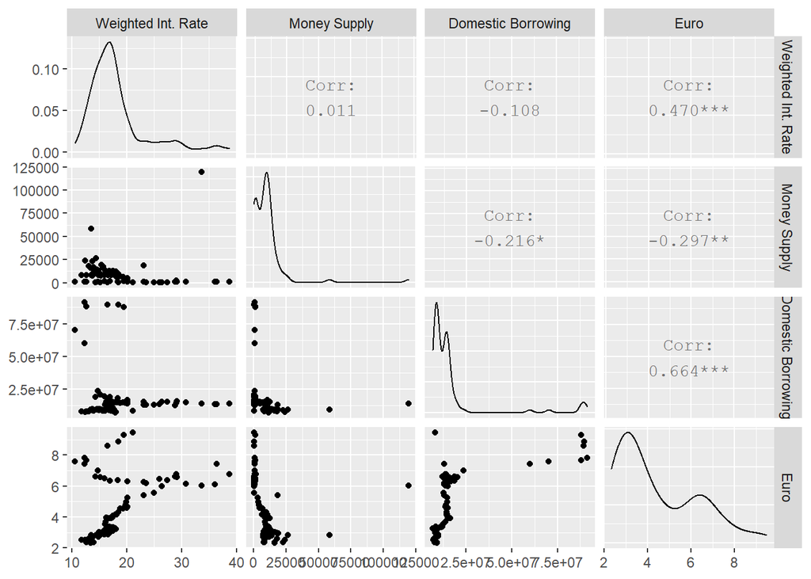

Additionally, the correlation matrix is as follows:

```
##                    Weighted Int. Rate Money Supply Domestic Borrowing
## Weighted Int. Rate         1.00000000   0.01072196         -0.1081162
## Money Supply               0.01072196   1.00000000         -0.2162606
## Domestic Borrowing        -0.10811625  -0.21626064          1.0000000
## Euro                       0.46963503  -0.29736968          0.6641002
##                          Euro
## Weighted Int. Rate  0.4696350
## Money Supply       -0.2973697
## Domestic Borrowing  0.6641002
## Euro                1.0000000
```

Using this correlation matrix, another visualization can be made which is also presents a lot of information with the help of colors:

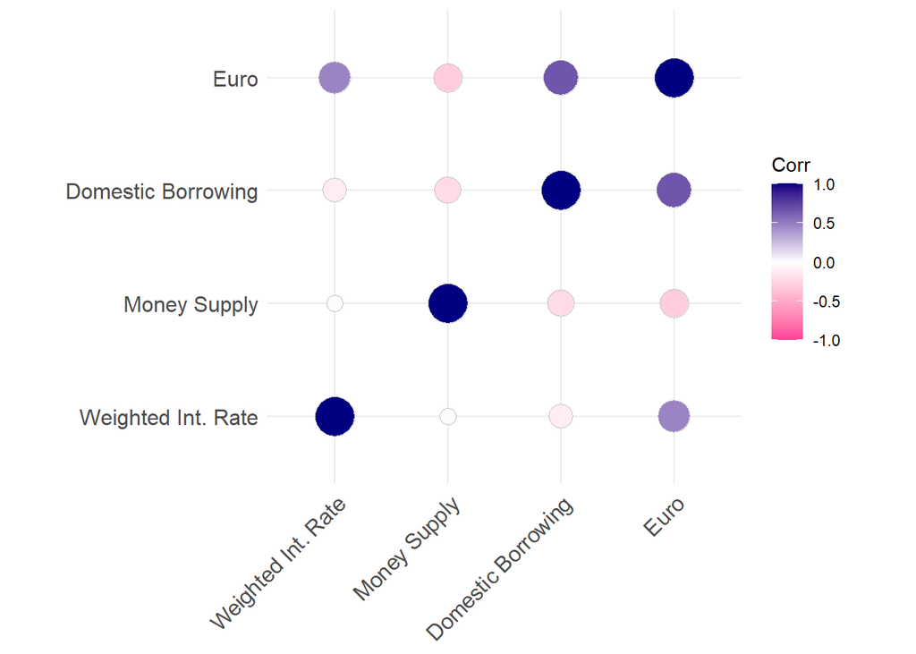

We had the same results with fancier representation, we can see the significant correlation between euro and interest rates, or euro and domestic borrowing.

Briefly, The Pearson correlation coefficient is used to measure the strength of a linear association between two variables, where the value *r = 1* means a perfect positive correlation and the value *r = -1* means a perfect negative correlation.

### The correlation between the weighted interest rates and money supply:

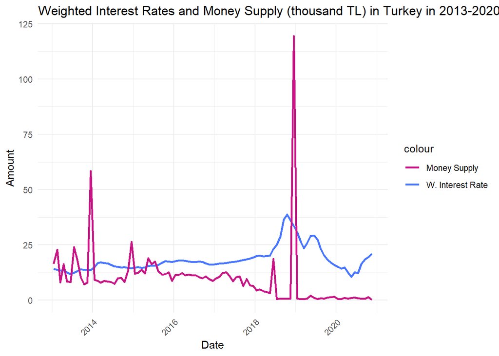

As we can see above, there seems not a significant correlation exists. There are two sudden increases in the money supply after 2018 as we have seen in the histograms prior. Similarly, there are two jumps in the interest rates at close dates. However, this small similarity will probably be not enough to say there is a correlation. To clearly understand the relationship between these two, we continue with the correlation test:

```
##
##  Pearson's product-moment correlation
##
## data:  corr_DT$`Weighted Int. Rate` and corr_DT$`Money Supply`
## t = 0.1034, df = 93, p-value = 0.9179
## alternative hypothesis: true correlation is not equal to 0
## 95 percent confidence interval:
##  -0.1912343  0.2118073
## sample estimates:
##        cor
## 0.01072196
```

If the p-value is < 5%, then the correlation between the two data is significant. However, we fail to reject the null hypothesis which was saying that the true correlation between these two data is equal to 0. There is not a significant correlation by looking at the p-value and correlogram as well.

### Correlation between the weighted interest rate and domestic borrowing:

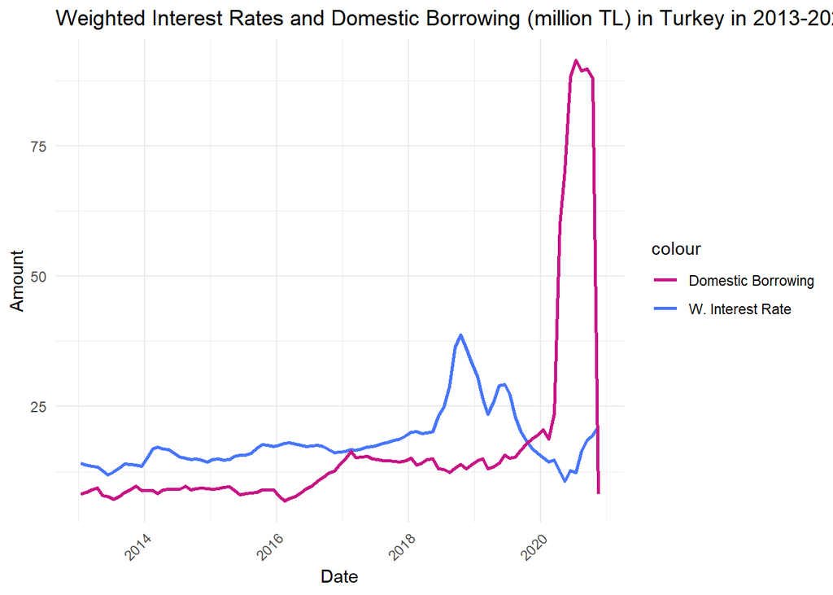

This time, we have a comparison of weighted interest rates and domestic borrowing. Again, although graphs seem not correlated, we should provide statistical proof that the correlation is significant or not:

```
##
##  Pearson's product-moment correlation
##
## data:  corr_DT$`Weighted Int. Rate` and corr_DT$`Domestic Borrowing`
## t = -1.0488, df = 93, p-value = 0.297
## alternative hypothesis: true correlation is not equal to 0
## 95 percent confidence interval:
##  -0.30305565  0.09550788
## sample estimates:
##        cor
## -0.1081162
```

Although the p-value of this one is smaller, it is still not enough for us to reject the null hypothesis. As it was seen before from the correlogram, the correlation is not significant.

### Correlation between the weighted interest rate and exchange rate

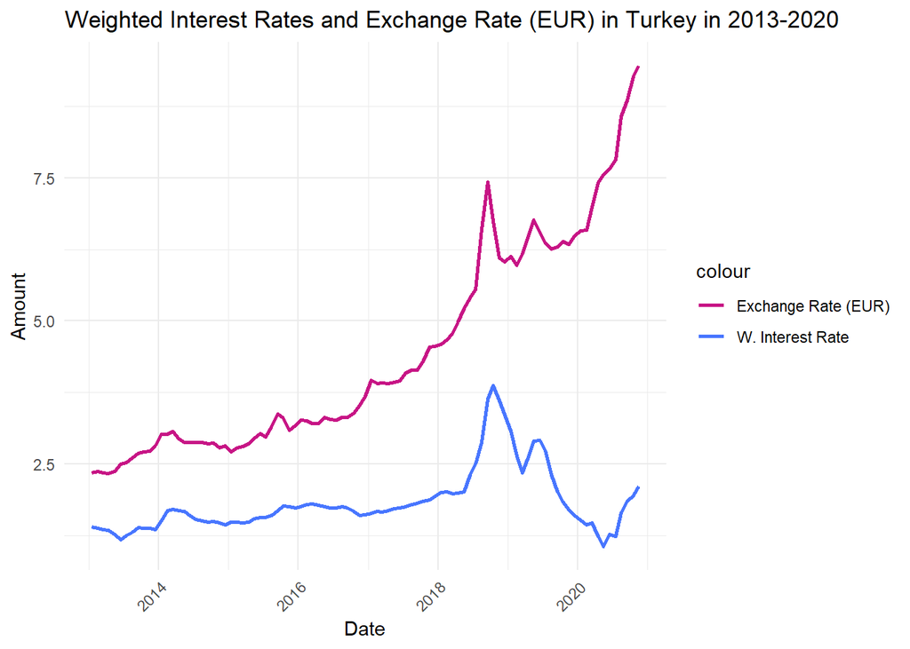

To visualize the relation better, I preferred to use $‰$ instead of %. This time, we can see a high similarity between the two measures. For the first 2-3 years are almost the same; moreover, there are two peaks in both of the measures which happen on the same dates. Looking at the above graph, we can guess that there is a strong relationship between these two, but again, we need a scientific explanation which will be provided with a correlation test:

```
##
##  Pearson's product-moment correlation
##
## data:  corr_DT$`Weighted Int. Rate` and corr_DT$Euro
## t = 5.1299, df = 93, p-value = 1.577e-06
## alternative hypothesis: true correlation is not equal to 0
## 95 percent confidence interval:
##  0.2961203 0.6131430
## sample estimates:
##      cor
## 0.469635
```

This time, the p-value is very small which will allow us to reject the null hypothesis. In other words, it is safe to say the correlation between weighted interest rates and euro, is not equal to zero, and significant.

As is mentioned above, we see that euro has a significant correlation between the other three measures. This is not surprising since changes in exchange rates in open economies affect key economic indicators. According to my research: increases in the exchange rate initially increase exports and increase national income. In parallel with the increase in national income, the increase in the demand for money causes the interest rates to rising and vice versa. Even though we have not a significant correlation between interest rates and money supply, the euro exchange rate seems to affect all of these measures.

# Conclusion

In this study, the relationship between weighted interest rates and three other measures was discussed. These three measures were money supply in the Turkish Republic Central Bank, domestic borrowing of Turkey, and the exchange rate (EUR). Put differently, the research question was **“Are interest rates statistics related to exchange rates, domestic borrowing, the supply of money?”**. Data is taken from [EVDS](https://evds2.tcmb.gov.tr/) on a monthly level for the years from 2013 to 2020. Histograms, scatter plots and correlation analysis was used to comment on the relationship and explain the test results.

**For the rmd file and codes of this report [click](https://bu-ie-360.github.io/fall20-ilaydatutal/files/Homework2.Rmd)**

**References:**

- [EVDS](https://evds2.tcmb.gov.tr/)
- [STHDA](http://www.sthda.com/english/)
- [Detailed Data Table](https://cran.r-project.org/web/packages/data.table/vignettes/datatable-intro.html)
- [Visualization](https://www.r-graph-gallery.com/index.html)